# Grundlegende Programmiertechniken - Blatt 3

# Aufgabe 1: Primzahltester

Schreiben Sie ein Programm und speichern Sie es als *Primzahltester.py* ab. Ihr Programm soll einen Integer als **Programmparameter** erhalten. Dann soll es überprüfen, ob es sich bei der Zahl um eine Primzahl handelt. Wenn die Zahl eine Primzahl ist, soll *True* ausgegeben werden, ansonsten *False*.

Tipp: Eine Primzahl ist eine Zahl, die nur durch 1 und sich selbst teilbar ist. Die Zahlen 0, 1 und negative Zahlen sind keine Primzahlen.

```python
%%writefile Primzahltester.py
import sys

zahl = int(sys.argv[1])

if zahl >= 2:
    for teiler in range(2, zahl):
        if zahl % teiler == 0:
            print("False")
            break
    else:
        print("True")
else:
    print("False")
```

```
Overwriting Primzahltester.py
```

## Aufgabe 2: Summe

Schreiben Sie ein Programm und speichern Sie es als *Summe.py* ab. Ihr Programm soll den Nutzer auffordern, eine beliebige Kommazahl einzugeben, und darauf hinweisen, dass die Eingabe 0 das Programm beendet. Wenn der Nutzer Zahlen außer 0 eingibt, soll ein weiteres Mal zur Eingabe aufgefordert werden. Wenn der Nutzer die 0 eingibt, soll das Programm die Summe aller eingegebenen Zahlen ausgeben.

Ein beispielhafter Aufruf könnte so aussehen:

```
$ python3 Summe.py
Dieses Programm berechnet die Summe der eingegebenen Zahlen. Eingabe 0 beendet das Programm.
Bitte geben Sie eine Kommazahl ein: 2.1
Bitte geben Sie eine Kommazahl ein: 1.1
Bitte geben Sie eine Kommazahl ein: 0
Summe: 3.2
```

```python
print("Dieses Programm berechnet die Summe der eingegebenen Zahlen. Eingabe 0 beendet das Programm.")

summe = 0
eingabe = 1

while eingabe != 0:
    eingabe = float(input("Bitte geben Sie eine Kommazahl ein: "))
    summe += eingabe

print("Summe:", summe)
```

```
Dieses Programm berechnet die Summe der eingegebenen Zahlen. Eingabe 0 beendet das Programm.
```

```
Summe: 14.1
```

# Arrays/Listen

## Generelles zu Listen

Was ist die Ausgabe?

```python
arr = [1, 2, 3]

print(arr[2])
```

```
3
```

```python
arr = [1, 2, 3]

print(arr[3])
```

```
---------------------------------------------------------------------------
IndexError                                Traceback (most recent call last)
<ipython-input-7-e368f85ee8fd> in <module>
      1 arr = [1, 2, 3]
      2
----> 3 print(arr[3])

IndexError: list index out of range
```

```python
arr = [1, 2, 3]

print(arr[-1])
```

```
3
```

```python
arr = [1, 2, 3]
arr += 4

print(arr)
```

```
---------------------------------------------------------------------------
TypeError                                 Traceback (most recent call last)
<ipython-input-17-3187c6eb94cc> in <module>
      1 arr = [1, 2, 3]
----> 2 arr += 4
      3
      4 print(arr)

TypeError: 'int' object is not iterable
```

```python
arr = [1, 2, 3]
arr += [4]

print(arr)
```

```
[1, 2, 3, 4]
```

```python
arr = [42]*42

print(arr)
```

```
[42, 42, 42, 42, 42, 42, 42, 42, 42, 42, 42, 42, 42, 42, 42, 42, 42, 42, 42, 42, 42, 42, 42, 42, 42, 42, 42, 42, 42, 42, 42, 42, 42, 42, 42, 42, 42, 42, 42, 42, 42, 42]
```

```python
arr = [1, 2, 3] # range(1, 4)

for i in arr:
    print(i)
```

```
1
2
3
```

## Slicing

Was ist die Ausgabe?

```python
arr = [1, 2, 3, 4, 5]
```

```python
print(arr[1:4])
```

```
[2, 3, 4]
```

```python
print(arr[1:])
```

```
[2, 3, 4, 5]
```

```python
print(arr[:3])
```

```
[1, 2, 3]
```

```python
print(arr[:-2])
```

```
[1, 2, 3]
```

```python
print(arr[:])
```

```
[1, 2, 3, 4, 5]
```

```python
print(arr[::-1])
```

```
[5, 4, 3, 2, 1]
```

```python
print(arr[1::2])
```

```
[2, 4]
```

```python
print(arr[-2:1:-1])
```

```
[4, 3]
```

## Slicings sind toll

```python
import numpy as np
import matplotlib.pyplot as plt
import cv2

def show(img_data):
    fig, ax = plt.subplots(1)
    ax.imshow(img_data)
    plt.show()

cat = cv2.imread('cat.jpg')[:,:,::-1]
```

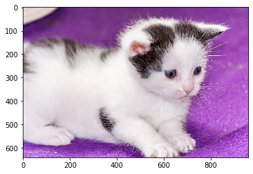

```python
img = cat
show(img)
```

Das Array cat ist wie folgt aufgebaut:

```
[
    [pixel11, pixel12, pixel13, pixel14, ...],
    [pixel21, pixel22, pixel23, pixel24, ...],
    [pixel31, pixel32, pixel33, pixel34, ...],
    [pixel41, pixel42, pixel43, pixel44, ...],
    ...
]
```

Wobei jeder Pixel auch ein 3-elementiges Array ist

```
(z.B. [150, 255, 0])
      [R  , G  , B]
```

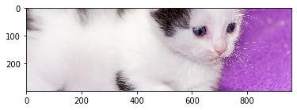

```python
img = cat[200:500]
show(img)
```

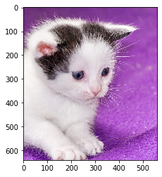

```python
img = [zeile[400:] for zeile in cat]
show(img)
```

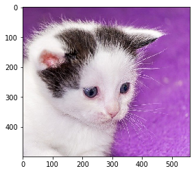

```python
img = [zeile[400:] for zeile in cat[:500]]
show(img)
```

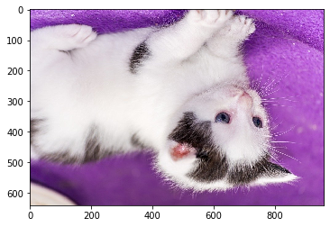

```python
img = cat[::-1]
show(img)
```

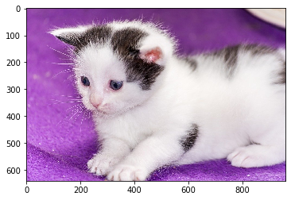

```python
img = [zeile[::-1] for zeile in cat]
show(img)
```

julian.hoever@stud.uni-due.de